# Básico de Álgebra Linear

Guilherme Garcia e Diogo Melo

19 de Maio de 2026

# Objetivos

O objetivo deste tutorial é introduzir alguns conceitos básicos de álgebra linear. Esta disciplina possui um número muito grande de aplicações, que vão da computação gráfica até a previsão do tempo. No contexto deste curso, alguns conceitos centrais em genética quantitativa são expressos através de vetores e matrizes, os objetos centrais desta introdução.

# Vetores

Existem três concepções básicas a respeito do que são vetores. Talvez, a concepção mais próxima de nós biólogos é a de um vetor como uma coleção de valores numéricos. Imagine que você toma algumas medidas lineares de uma coleção de organismos: a largura da cabeça, o comprimento da cabeça e o comprimento da cauda, por exemplo. Para cada indivíduo de sua amostra, você tem uma coleção de três valores, e é razoável pensar que cada indivíduo é representado por uma concatenação destes três valores,
$$\boldsymbol{a} = (x, y, z); \quad \boldsymbol{b} = (x', y',
z') ...$$
em que $\boldsymbol{a}$ e $\boldsymbol{b}$ se referem a dois indivíduos distintos na amostra. Claro que não precisamos nos ater a apenas três mensurações, de modo que esse vetor pode representar quantas medidas gostaríamos de tomar, mas é melhor manter as ideias em dimensionalidade baixa, por enquanto.

Uma outra representação para vetores, talvez mais próxima da realidade dos físicos é imaginar um vetor como uma seta. Para eles, várias quantidades de interesse são naturalmente representadas como vetores, como por exemplo a velocidade de uma partícula em uma trajetória ou o campo gravitacional da Terra. Cada valor na concatenação acima pode ser concebido como a coordenada deste vetor em um eixo, e podemos representar graficamente cada vetor como uma seta que sai da origem destas coordenadas. Por exemplo, os vetores
$$\boldsymbol{\vec{u}}= (0, -4); \quad \boldsymbol{\vec{v}}= (2, 2); \quad
\boldsymbol{\vec{w}}= (-1, 3)$$
podem ser representados graficamente no R usando o seguinte código:

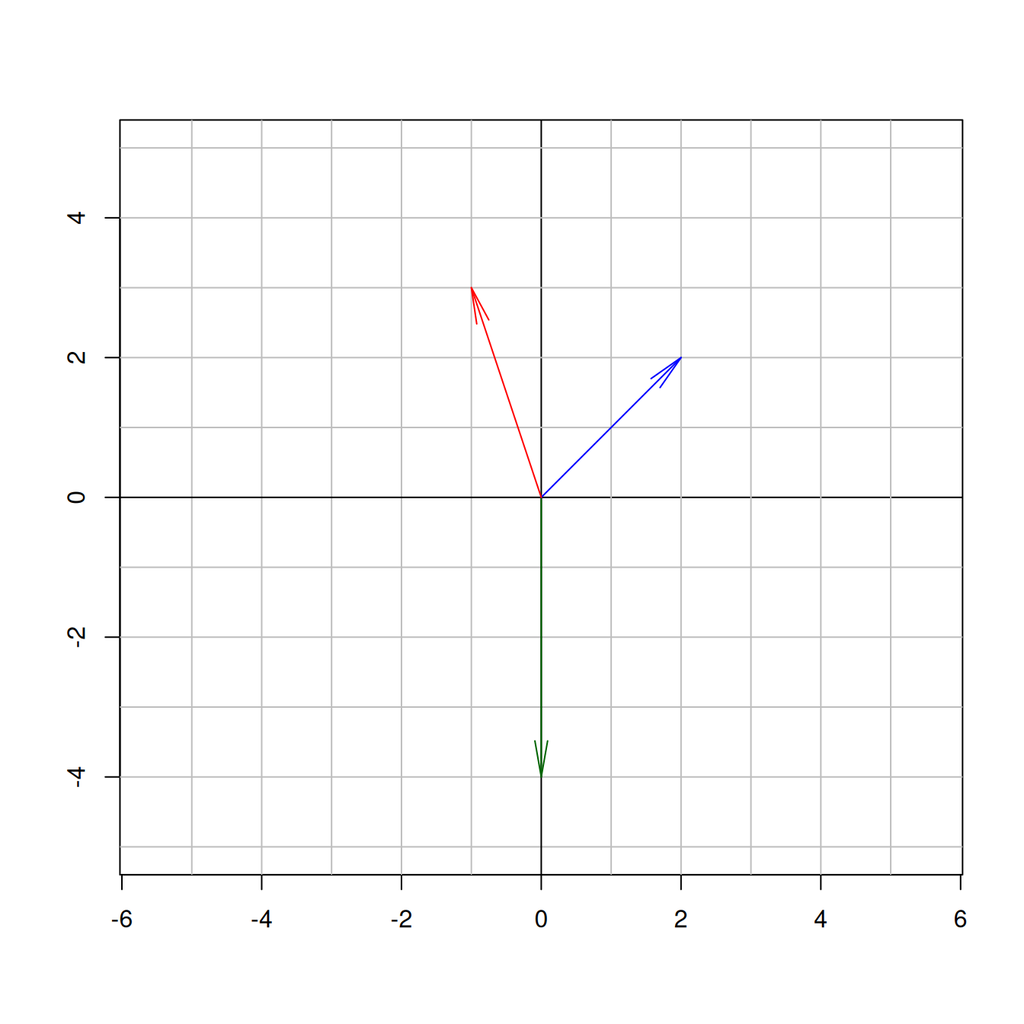

```r
# definindo alguns vetores
u <- c(0, -4)
v <- c(2, 2)
w <- c(-1, 3)

# essa pequena função facilita bastante representar vetores na janela gráfica
plotVector <- function(v, color = 'black', width = 1)
    arrows(x0 = 0, y0 = 0, x1 = v[1], y1 = v[2],
           col = color, lwd = width, angle = 10)

# vamos apenas inicializar uma região gráfica vazia;
# xlim e ylim se referem aos limites desta janela;
# xlab e ylab são os nomes de cada eixo (nada, no caso).
plot(NA, xlim = c(-5, 5), ylim = c(-5, 5), xlab = '', ylab = '', asp = 1)

# vamos também desenhar linhas que representam o sistema de coordenadas
for(i in (-5):5)
    {
        abline(h = i, col = ifelse(i != 0, 'grey', 'black'))
        abline(v = i, col = ifelse(i != 0, 'grey', 'black'))
    }

# agora, podemos usar a função que desenha vetores
plotVector(u, 'darkgreen')
plotVector(v, 'blue')
plotVector(w, 'red')
```

**Importante**: Idealmente, para todo código neste tutorial, seria bom você colá-lo em um *script* no RStudio e executá-lo mudando algumas coisas só para ver o que acontece. No caso deste código acima, você pode plotar outros vetores, por exemplo, ou talvez mudar as cores.

Uma terceira concepção é mais próxima da realidade dos matemáticos, que em geral pensam as coisas na forma de conjuntos, as operações que podemos fazer com elementos neste conjunto, e as propriedades destas operações. Nesta concepção, a representação mais adequada para um vetor é aquela que facilita sua compreensão do que está acontecendo. No entanto, é importante notar que, qualquer que seja a operação feita com um vetor ou vetores, haverá duas formas de imaginar esta operação: uma relacionada a representá-los sob a forma de listas de números, outra relacionada a representá-los como setas.

Inicialmente, podemos fazer duas coisas com vetores: somá-los e multiplicá-los por números. Para somar dois vetores, a forma mais simples de pensar a princípio é simplesmente somando suas entradas correspondentes individualmente:
$$\boldsymbol{\vec{u}}= (u_1, u_2); \boldsymbol{\vec{v}}= (v_1, v_2)
\Rightarrow \boldsymbol{\vec{u}}+ \boldsymbol{\vec{v}}= (u_1 + v_1, u_2
+ v_2)$$
Além disso, podemos pensar nesta soma como uma concatenação de ações. Neste código, mostramos que a soma de dois vetores, quando representados sob a forma de setas, corresponde a andar na direção e distância dada pelo primeiro vetor, depois andar a direção e distância dada pelo segundo vetor.

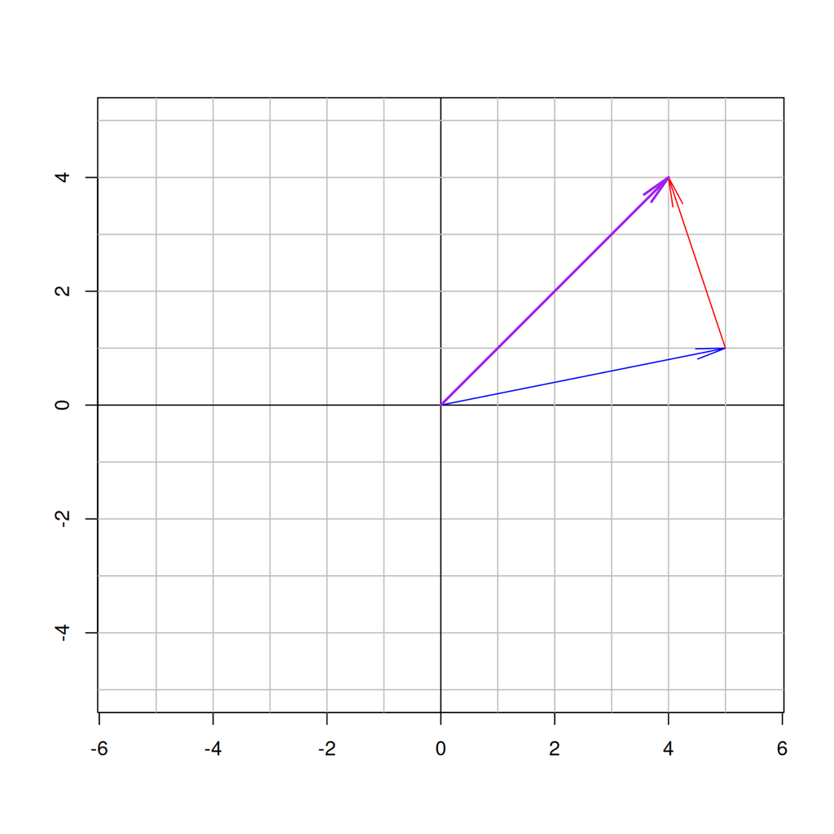

```r
u <- c(5, 1)
v <- c(-1, 3)

# esta função desenha um vetor 'v' a partir da ponta de outro vetor 'u'
plotDislocatedVector <- function(v, u, color = 'black', width = 1)
    arrows(x0 = u[1], y0 = u[2], x1 = u[1] + v[1], y1 = u[2] + v[2],
           col = color, lwd = width, angle = 10)

# novamente, vamos inicializar um gráfico vazio
plot(NA, xlim = c(-5, 5), ylim = c(-5, 5), xlab = '', ylab = '', asp = 1)

for(i in (-5):5)
    {
        abline(h = i, col = ifelse(i != 0, 'grey', 'black'))
        abline(v = i, col = ifelse(i != 0, 'grey', 'black'))
    }

plotVector(u, 'blue')
plotDislocatedVector(v, u, 'red')
plotVector(u + v, 'purple', width = 2)
```

Multiplicar um vetor por um número é também bastante direto, basta apenas multiplicar suas entradas individuais pelo número:
$$\boldsymbol{\vec{u}}= (u_1, u_2) \Rightarrow \alpha \cdot
\boldsymbol{\vec{u}}= (\alpha \cdot u_1, \alpha \cdot u_2)$$
Neste contexto, chamamos de *escalar* este valor $\alpha$ que multiplica o vetor $\boldsymbol{\vec{u}}$.

### Exercício 1

Tente modificar os pedaços de código utilizados anteriormente para representar graficamente o produto entre vetores e escalares. Depois, responda as seguintes perguntas:

1. O que acontece com um vetor após esta operação?
2. O que acontece se você multiplicar um vetor por um número negativo?

## Norma e Direção

Podemos caracterizar um vetor por sua **norma**, ou seja, o comprimento da seta que representa o vetor, e por sua **direção**, ou seja, para onde o vetor aponta. A norma de um vetor pode ser calculada em duas dimensões pela relação de Pitágoras:
$$\|\boldsymbol{\vec{u}}\| = \sqrt{u_1^2 + u_2^2}$$
mas, independente do número de dimensões representadas no vetor, a norma de um vetor é obtida como sendo a raiz quadrada da soma de todas as coordenadas ao quadrado.

Uma operação que fazemos comumente é *normalizar* um vetor, isto é, dividir os elementos do vetor por sua norma, de modo que a norma deste novo vetor será unitária.

### Exercício 2

Leia atentamente e execute o código a seguir:

```r
require(evolqg)

# o pacote evolqg possui uma função que normaliza um vetor
?Normalize

# vamos gerar alguns vetores aleatórios em duas dimensões

# primeiro, vamos gerar alguns números advindos de uma distribuição normal padrão
rand.vec <- rnorm(100)

# agora, vamos organizar esses números como vetores em uma tabela
rand.vec <- matrix(rand.vec, nrow = 50, ncol = 2)

# cada vetor aleatório corresponde a uma linha desta tabela
# quero normalizar cada vetor, utilizando a função aaply
?aaply
norm.vec <- aaply(rand.vec, 1, Normalize)

# agora, vamos plotar estes vetores
# aqui, não vou me preocupar em representá-los como setas
# apenas o ponto no plot entre suas coordenadas é suficiente
plot(norm.vec, asp = 1, pch = 20)
```

1. Os pontos parecem desenhar uma forma em particular? Que forma é essa?
2. Aumente o número de vetores gerados para mil.
3. Você consegue elaborar uma razão para esta forma estar sendo gerada?

## Bases

Bases são um conceito bastante simples, mas que possui muitas consequencias importantes. De maneira simples, posso escrever um vetor qualquer no espaço bidimensional da seguinte forma:
$$\boldsymbol{\vec{u}}= \begin{bmatrix} u_1 \\ u_2 \\ \end{bmatrix}
\Rightarrow
\boldsymbol{\vec{u}}= u_1 \cdot \begin{bmatrix} 1 \\ 0 \\ \end{bmatrix}
+
u_2 \cdot \begin{bmatrix} 0 \\ 1 \\ \end{bmatrix}$$
introduzindo também a notação de vetores como matrizes-coluna. É importante notar que qualquer vetor bidimensional pode ser escrito desta forma, como uma *combinação linear* dos vetores $(1, 0)$ e $(0, 1)$. Basta substituir os valores $u_1$ e $u_2$ por quaisquer pares de números, e eu obtenho um vetor no espaço bidimensional. Estes dois vetores são importantes o bastante para receber nomes especiais:
$$\boldsymbol{\hat \imath}= \begin{bmatrix} 1 \\ 0 \\ \end{bmatrix};
\boldsymbol{\hat \jmath}= \begin{bmatrix} 0 \\ 1 \\ \end{bmatrix}.$$
Juntos, $\boldsymbol{\hat \imath}$ e $\boldsymbol{\hat \jmath}$ constituem o que chamamos de *base canônica* do espaço bidimensional (que, pra economizar palavras, vamos chamar de $\mathbb{R}^2$ a partir de agora). Daí podemos escrever $\boldsymbol{\vec{u}}$ como
$$\boldsymbol{\vec{u}}= u_1 \boldsymbol{\hat \imath}+ u_2 \boldsymbol{\hat
\jmath}$$
que é mais uma forma de representar um vetor. Como $\boldsymbol{\hat \imath}$ e $\boldsymbol{\hat \jmath}$ podem ser combinados de modo a produzir qualquer vetor no $\mathbb{R}^2$, dizemos que estes vetores *geram* o espaço.

Mas, somente estes dois vetores são capazes de gerar o espaço bidimensional?

Existem pares de vetores que não são capazes de fazê-lo?

### Exercício 3

1. Escreva o vetor $(5, 1)$ como uma combinação linear dos vetores $(-2, 1)$ e $(1, 3)$.
- *Dica*: Vamos escrever o problema:
  $$\begin{bmatrix} 5 \\ 1 \\ \end{bmatrix} = \alpha \begin{bmatrix} -2 \\ 1
  \\ \end{bmatrix} +
  \beta \begin{bmatrix} 1 \\ 3 \\ \end{bmatrix}.$$
- É possível achar valores para $\alpha$ e $\beta$?

```r
u <- c(-2, 1)
v <- c(1, 3)
w <- c(5, 1)

# aqui vão suas soluções
# descomente o código para executar essas linhas quando você achar as soluções
# alpha <-
# beta <-

plot(NA, xlim = c(-5, 5), ylim = c(-5, 5), xlab = '', ylab = '', asp = 1)

for(i in (-5):5)
    {
        abline(h = i, col = ifelse(i != 0, 'grey', 'black'))
        abline(v = i, col = ifelse(i != 0, 'grey', 'black'))
    }

# confira sua solução
# enquanto vc não achar alpha e beta e atribuir valores
# esse código não vai funcionar
plotVector(alpha * u, 'darkgreen')
plotDislocatedVector(beta * v, alpha * u, 'blue')
plotVector(w, 'red', width = 2)
# se estiver certo a ponta dos vetores vai coincidir
```

2. Escreva o mesmo vetor $(5, 1)$ como combinação linear dos vetores $(-2, 1)$ e $(2, -1)$.

```r
# o mesmo código deve ajudar você a entender o que está acontecendo nesta situação
u <- c(-2, 1)
v <- c(2, -1)
w <- c(5, 1)

plot(NA, xlim = c(-5, 5), ylim = c(-5, 5), xlab = '', ylab = '', asp = 1)

for(i in (-5):5)
    {
        abline(h = i, col = ifelse(i != 0, 'grey', 'black'))
        abline(v = i, col = ifelse(i != 0, 'grey', 'black'))
    }

plotVector(u, 'darkgreen')
plotVector(v, 'blue')
plotVector(w, 'red', width = 2)
```

# Matrizes

Intuitivamente, matrizes são tabelas de números, algo como
$$\mathbf{A} = \begin{bmatrix}
a & b \\
c & d \\
\end{bmatrix}.$$
Neste tutorial, gostaria de enfatizar seu papel geométrico como transformação linear, ao invés de focar na álgebra, como fazem na Educação Básica. Neste contexto, o que são trasformações? Você pode pensar em uma função, como $f(x) = x^2$, que recebe um número como entrada e retorna um número como saída. Matrizes podem ser pensadas como funções quando observamos seu efeito sobre um vetor. Assim, definimos uma função $f(\boldsymbol{\vec{v}}) = \mathbf{A} \boldsymbol{\vec{v}}$, que recebe um vetor $\boldsymbol{\vec{v}}$ e retorna um outro vetor $\boldsymbol{\vec{w}}= f(\boldsymbol{\vec{v}})$. Neste momento inicial, não importa como exatamente computamos esta função. Por exemplo, considere a matriz
$$\mathbf{R} =
\begin{bmatrix}
0 & 1 \\
-1 & 0 \\
\end{bmatrix}.$$
Vamos ver o que ela faz com um vetor? Ou com vários vetores.

```r
## primeiro vamos definir R
R <- matrix(c(0, 1,
              -1, 0), byrow = TRUE, nrow = 2)

## e dar uma olhada nesta matriz
R
```

```
##      [,1] [,2]
## [1,]    0    1
## [2,]   -1    0
```

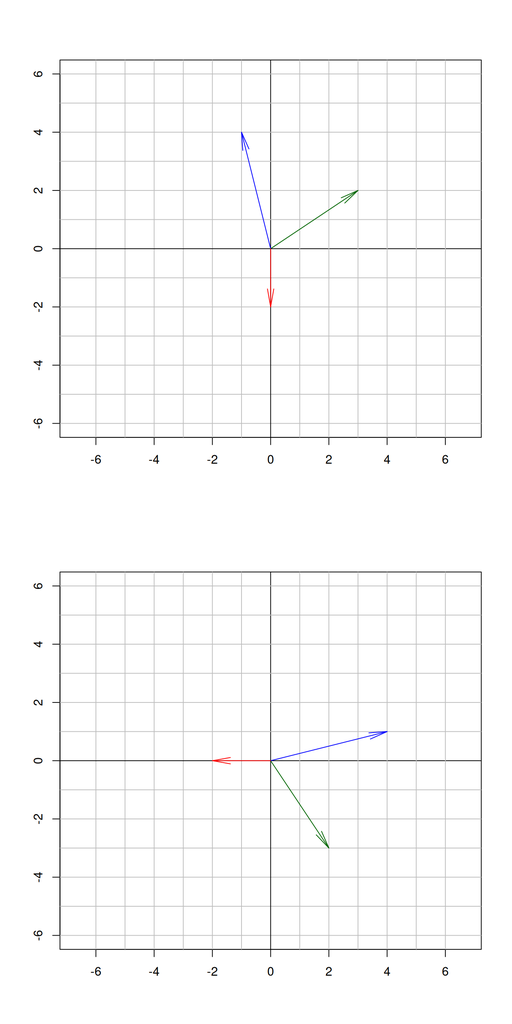

```r
## vamos definir alguns vetores
u <- c(3, 2)
v <- c(-1, 4)
w <- c(0, -2)

## e operar sobre eles com R
f.u <- R %*% u
f.v <- R %*% v
f.w <- R %*% w

## essa operação aí em cima representa a multiplicação de matrizes e vetores
## por isso eu disse que você não precisa se preocupar com isso

## vou usar esse código bastante, então vamos fazer uma pequena função
plotEmptyCanvas <- function()
    {
        plot(NA, xlim = c(-6, 6), ylim = c(-6, 6), xlab = '', ylab = '', asp = 1)
        for(i in (-6):6)
        {
            abline(h = i, col = ifelse(i != 0, 'grey', 'black'))
            abline(v = i, col = ifelse(i != 0, 'grey', 'black'))
        }
    }

par(mfrow = c(2, 1))

# plotar os vetores que entram
plotEmptyCanvas()
plotVector(u, 'darkgreen')
plotVector(v, 'blue')
plotVector(w, 'red')

# e os vetores que saem
plotEmptyCanvas()
plotVector(f.u, 'darkgreen')
plotVector(f.v, 'blue')
plotVector(f.w, 'red')
```

Esta matriz rotaciona cada vetor 90 graus em sentido horário. Não estende ou muda os ângulos entre os vetores. Naturalmente, $\mathbf{R}$ é uma *matriz de rotação*. O próximo exemplo deixa mais claro o que entendemos por transformação linear. Considere a matriz
$$\mathbf{S} =
\begin{bmatrix}
2 & 1 \\
0 & 1 \\
\end{bmatrix}.$$
Vamos ver o que ela faz com um quadrado.

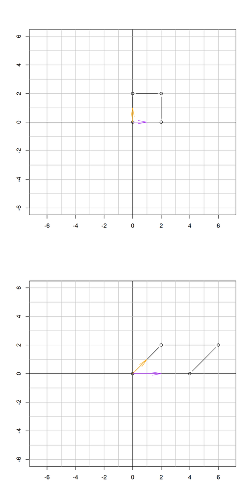

```r
## vamos desenhar um quadrado
quadrado <- matrix(c(0, 0,
                     0, 2,
                     2, 2,
                     2, 0), byrow = TRUE, nrow = 4)

S <- matrix(c(2, 1,
              0, 1), byrow = TRUE, nrow = 2)

f.quadrado <- S %*% t(quadrado)
## esse função t() troca as linhas pelas colunas da matriz quadrado
## isso garante que cada aresta do quadrado seja um vetor coluna pra ser multiplicado

f.quadrado <- t(f.quadrado)
## cada aresta do quadrado transformado é uma linha agora

## vamos também olhar para o que acontece com os vetores que definem a base canônica do R2
ihat <- c(1, 0)
jhat <- c(0, 1)

f.ihat <- S %*% ihat
f.jhat <- S %*% jhat

par(mfrow = c(2, 1))

plotEmptyCanvas()
points(quadrado, type = 'b')
plotVector(ihat, 'purple')
plotVector(jhat, 'orange')

plotEmptyCanvas()
points(f.quadrado, type = 'b')
plotVector(f.ihat, 'purple')
plotVector(f.jhat, 'orange')
```

Essa matriz distorce o quadrado, o transformando em um paralelogramo, mas note que esta distorção preserva o paralelismo entre os lados da figura resultante. Esta propriedade é uma das condições que define uma transformação *linear*. Linhas retas na entrada se mantém retas na saída. A outra propriedade importante é que a origem deve ficar onde está após passar pela transformação, mas para estas funções definidas apenas como um um produto entre matriz e vetor, isto é garantido.

No exemplo, também aproveitamos e mostramos o destino dos vetores $\boldsymbol{\hat \imath}$ e $\boldsymbol{\hat \jmath}$ após a transformação. Estes vetores vão parar em
$$f(\boldsymbol{\hat \imath}) = \begin{bmatrix} 2 \\ 0 \\ \end{bmatrix};
f(\boldsymbol{\hat \jmath}) = \begin{bmatrix} 1 \\ 1 \\ \end{bmatrix};$$
que são exatamente as colunas da matriz $\mathbf{S}$! De fato, podemos definir qualquer transformação linear a partir do que acontece com $\boldsymbol{\hat \imath}$ e $\boldsymbol{\hat \jmath}$, e escrever qualquer vetor no espaço transformado como sendo uma combinação linear de $f(\boldsymbol{\hat \imath})$ e $f(\boldsymbol{\hat \jmath})$:
$$\mathbf{S}\boldsymbol{\vec{v}}=
v_1 \begin{bmatrix} 2 \\ 0 \\ \end{bmatrix}
+ v_2 \begin{bmatrix} 1 \\ 1 \\ \end{bmatrix}$$
o que deixa muito mais claro o que fazer para multiplicar uma matriz por um vetor.

Note que a gente pode plotar tanto os vetores que entram nestas matrizes quanto os que saem porque ambas são matrizes com duas linhas e duas colunas. Estas matrizes quadradas são especiais porque o espaço de entrada e o espaço de saída possuem o mesmo número de dimensões.

## Exercício 4

Vamos considerar o que acontece com composições entre matrizes.

1. Obtenha o produto entre a matriz $\mathbf{R}$, definida no início desta seção, e os vetores $(2, 0)$ e $(1, 1)$. Escreva estes produtos na forma de combinações lineares entre as colunas da matriz $\mathbf{R}$.
2. Leia o código abaixo:

```r
### aqui a gente roda o paralelogramo
fg.quadrado <- t(R %*% t(f.quadrado))

plotEmptyCanvas()
points(fg.quadrado, type = 'b')
```

Este código aplica a matriz $\mathbf{R}$ sobre a saída de multiplicar as arestas do quadrado por $\mathbf{S}$. Você consegue escrever um código que faça o oposto (pega o quadrado, aplica $\mathbf{R}$, depois aplica $\mathbf{S}$ e mostra o resultado)?

3. As duas formas geradas são iguais?